# synDataGenerator

Eliza Duvall

2024-02-02

Functions to generate synthetic data - in my case, the synthetic data is a correlation matrix.

## Function

Parameters in the function:

- Lmin/Lmax = are the LOWEST correlation thresholds at a minimum and maximum (default is Lmin = 0.05 and Lmax = 0.3)
- Mmin/Mmax = are the MID correlation thresholds at a minimum and maximum (default is Mmin = 0.4 and Mmax = 0.7)
- Hmin/Hmax = are the HIGHEST correlation thresholds at a minimum and maximum (default is Hmin = 0.8 and Lmax = 0.99)
- nodes = the number of nodes to include
- Lfraction = the fraction of the nodes that should fall in the LOWEST correlation category
- Mfraction = the fraction of the nodes that should fall in the MID correlation category
- Hfraction = the fraction of the nodes that should fall in the HIGHEST correlation category

**NOTE:** The fractions should sum to 1

```r
synDataGenerator <- function(Lmin = 0.05, Lmax = 0.3,
                             Mmin = 0.4, Mmax = 0.7,
                             Hmin = 0.8, Hmax = 0.99,
                             nodes, Lfraction = 0.5,
                             Mfraction = 0, Hfraction = 0.5){
  numVals = ((nodes*nodes)-nodes)/2 # the number of edges/correlation values that need to be calculated

  vector <- runif(numVals*Lfraction, Lmin, Lmax) # randomly choose values for lower
  vector <- append(vector, runif(numVals*Mfraction, Mmin, Mmax)) # for mid
  vector <- append(vector, runif(numVals*Hfraction, Hmin, Hmax)) # for high

  mat <- matrix(0, nodes, nodes) # put together in a matrix
  mat[lower.tri(mat, diag=FALSE)] <- vector
  mat[upper.tri(mat, diag=FALSE)] <- vector

  return(mat)
}
```

## Test function default

Test this function

```r
defaultMatrix <- synDataGenerator(nodes = 10)
defaultMatrix
```

```
##             [,1]       [,2]       [,3]      [,4]       [,5]       [,6]
##  [1,] 0.00000000 0.29201484 0.22447557 0.2432857 0.12406081 0.24727450
##  [2,] 0.29201484 0.00000000 0.28241024 0.2316463 0.27475141 0.17968174
##  [3,] 0.22447557 0.28956474 0.00000000 0.2217182 0.06225101 0.10781768
##  [4,] 0.28241024 0.24727450 0.17990488 0.0000000 0.28956474 0.06514414
##  [5,] 0.24328575 0.17968174 0.08599167 0.9799252 0.00000000 0.24804425
##  [6,] 0.23164633 0.10781768 0.29750724 0.8193605 0.80121989 0.00000000
##  [7,] 0.22171818 0.06514414 0.17411068 0.8840844 0.90655799 0.83746489
##  [8,] 0.12406081 0.24804425 0.29406708 0.9807869 0.97570245 0.87647590
##  [9,] 0.27475141 0.21782519 0.88894611 0.9304471 0.89300634 0.86606404
## [10,] 0.06225101 0.05770379 0.96351135 0.8114133 0.96558241 0.95504406
##             [,7]      [,8]      [,9]     [,10]
##  [1,] 0.21782519 0.2940671 0.9304471 0.8764759
##  [2,] 0.05770379 0.8889461 0.8114133 0.8660640
##  [3,] 0.17990488 0.9635113 0.8012199 0.9550441
##  [4,] 0.08599167 0.9799252 0.9065580 0.8377703
##  [5,] 0.29750724 0.8193605 0.9757024 0.8192571
##  [6,] 0.17411068 0.8840844 0.8930063 0.8334106
##  [7,] 0.00000000 0.9807869 0.9655824 0.9245657
##  [8,] 0.83777027 0.0000000 0.8374649 0.8715809
##  [9,] 0.81925711 0.9245657 0.0000000 0.2920148
## [10,] 0.83341064 0.8715809 0.2920148 0.0000000
```

And let’s look at this correlation where color represents correlation strength

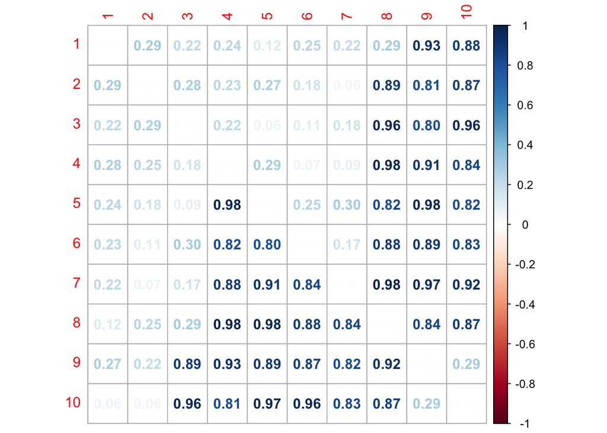

```r
corrplot(defaultMatrix, method = "number")
```

Generate a correlation matrix where there are blocks of highly correlation nodes

```r
m <- synDataGenerator(node = 22, Lfraction = 1, Hfraction = 0)
matH1 <- synDataGenerator(nodes = 10, Lfraction = 0, Hfraction = 1)
matH2 <- synDataGenerator(nodes = 5, Lfraction = 0, Hfraction = 1)
matH3 <- synDataGenerator(nodes = 7, Lfraction = 0, Hfraction = 1)

m[1:10, 1:10] <- matH1
m[11:15, 11:15] <- matH2
m[16:22, 16:22] <- matH3
```

## Generate highly correlated blocks

Let’s look at the correlation matrix in a nice plot, and we will see blocks of highly correlated notes

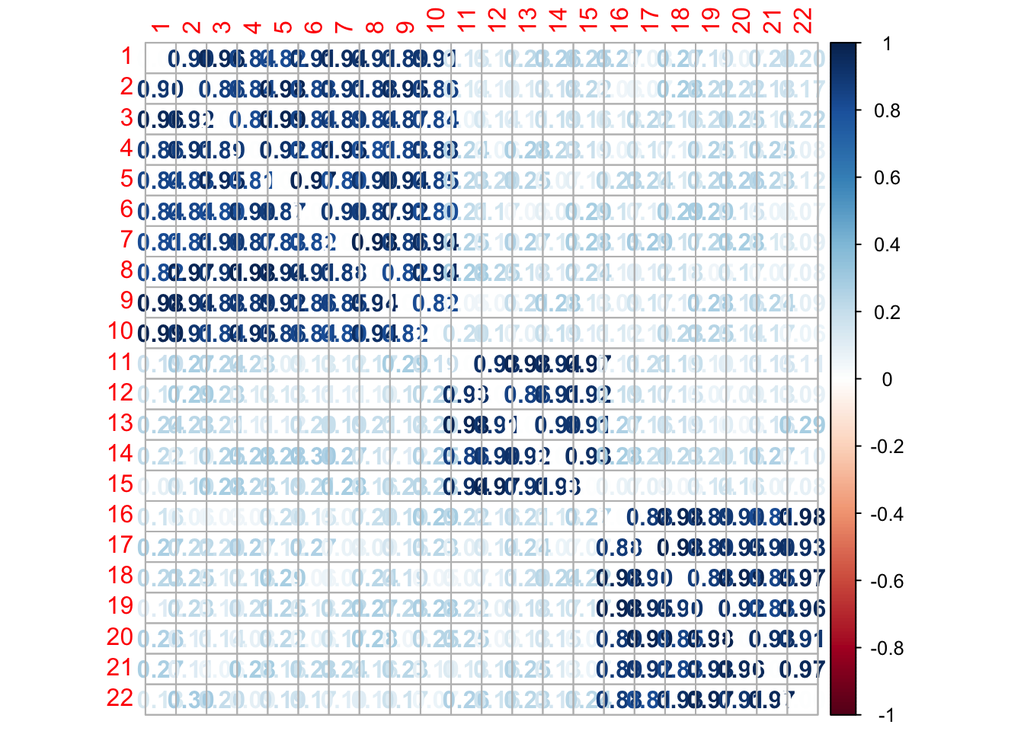

```r
corrplot(m, method = "number")
```

The purpose of creating this synthetic correlation is for network analysis. Let’s use this correlation matrix as an adjacency matrix and see what the complete network looks like. **Note,** a complete network is one in which all nodes are connected to all nodes.

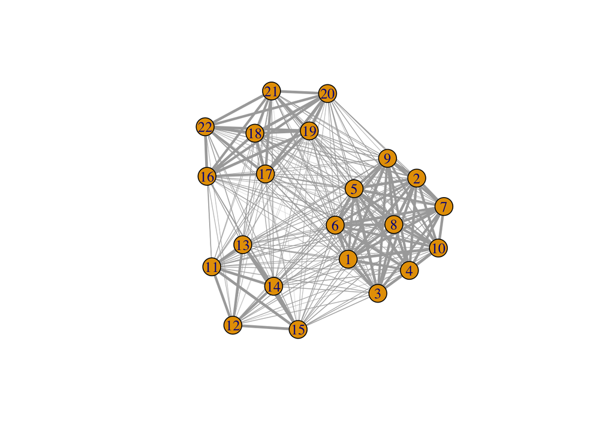

```r
g2 <- graph_from_adjacency_matrix(m, mode = "undirected", weighted = TRUE)
E(g2)$width <- E(g2)$weight*3
plot(g2)
```

And here we see the three neighborhoods/blocks of highly correlated values :)